# Hydro-GR4J

```r
# Verificar que quedó creado
MNT_UTM_sgrd = raster("1_Data_MNT/MNT_UTM_sgrd.sdat")

#Verificar la proyección
projection(MNT_UTM_sgrd)
```

```
[1] "+proj=utm +zone=18 +south +datum=WGS84 +units=m +no_defs"
```

Corregimos el MNT con el rellenado de vacios por lo que se genera el archivo demsink_fill.sgrd

```r
rsaga.geoprocessor(lib = "ta_preprocessor", 2,
                   param = list(DEM ="1_Data_MNT/MNT_UTM_sgrd.sgrd",
                                DEM_PREPROC= "1_Data_MNT/demsink_fill.sgrd"),
                   env = Env)
```

```
SAGA Version: 9.8.0 (64 bit)

library path: C:\Users\Legion\DOWNLO~1\SAGA-9~1.0_X\SAGA-9~1.0_X\tools\
library name: ta_preprocessor
library     : Preprocessing
tool        : Sink Removal
identifier  : 2
author      : O. Conrad (c) 2001
processors  : 20 [20]

Loading grid: 1_Data_MNT/MNT_UTM_sgrd.sgrd...
[Sink Removal] Execution started...

[Sink Removal] Parameters:

Grid System: 87.800000; 1289x 1704y; 336905.996493x 8532733.269265y
DEM: MNT_UTM_sgrd
Sink Route: <not set>
Preprocessed DEM: Preprocessed DEM
Method: Fill Sinks
Threshold: false
Epsilon: 0.001

Create index: MNT_UTM_sgrd [no sinks]
Find Pits
Find Outlets
Routing
Finalize

number of processed sinks: 10456
Initializing direction matrix...
I'm fillin'...

total execution time: 2000 milliseconds (02s)

[Sink Removal] Execution succeeded (02s)
Saving grid: 1_Data_MNT/demsink_fill.sgrd...
```

Seguidamente cargamos la salida de la estación, para este caso de ejemplo se ha cargado la estación SOCSI como punto final de la cuenca, para aplicar el modelo GR4J

```r
Est_Hidro = readOGR("4_Shp/","Estacion_Socsi")
Est_Hidro_utm <- spTransform(Est_Hidro, CRS(projection(MNT_utm)))
class(Est_Hidro_utm)
```

```
[1] "SpatialPointsDataFrame"
attr(,"package")
[1] "sp"
```

```r
proj4string(Est_Hidro_utm)
```

```
[1] "+proj=utm +zone=18 +south +datum=WGS84 +units=m +no_defs"
```

```r
coordinates(Est_Hidro_utm)
```

```
     coords.x1 coords.x2
[1,]  370463.3   8559312
```

```r
rsaga.geoprocessor(lib = "ta_hydrology", 4,
                   param = list(TARGET_PT_X = coordinates(Est_Hidro_utm)[1],
                                TARGET_PT_Y = coordinates(Est_Hidro_utm)[2],
                                ELEVATION = "1_Data_MNT/demsink_fill.sgrd",
                                AREA = "1_Data_MNT/Cuenca_canete.sgrd",
                                METHOD = 0),
                   env = Env)
```

```
SAGA Version: 9.8.0 (64 bit)

library path: C:\Users\Legion\DOWNLO~1\SAGA-9~1.0_X\SAGA-9~1.0_X\tools\
library name: ta_hydrology
library     : Hydrology
tool        : Upslope Area
identifier  : 4
author      : O.Conrad (c) 2001
processors  : 20 [20]

Loading grid: 1_Data_MNT/demsink_fill.sgrd...
[Upslope Area] Execution started...

[Upslope Area] Parameters:

Grid System: 87.800000; 1289x 1704y; 336905.996493x 8532733.269265y
Target Area: <not set>
Target X coordinate: 370463.32273565198
Target Y coordinate: 8559311.90342078
Elevation: demsink_fill
Sink Routes: <not set>
Upslope Area: Upslope Area
Method: Deterministic 8
Contour Length: false

Create index: demsink_fill

total execution time: 1000 milliseconds (01s)

[Upslope Area] Execution succeeded (01s)
Saving grid: 1_Data_MNT/Cuenca_canete.sgrd...
```

Finalmente se guarda el archivo Shp. de la cuenca delimitada

```r
rsaga.geoprocessor(lib = "shapes_grid", 6,
                   param = list(GRID = "1_Data_MNT/Cuenca_canete.sgrd",
                                POLYGONS = "4_Shp/Cuenca_canete_SAGA.shp",
                                CLASS_ALL = 1,
                                CLASS_ID = 100,
                                SPLIT = 0),
                   env = Env)
```

```
SAGA Version: 9.8.0 (64 bit)

library path: C:\Users\Legion\DOWNLO~1\SAGA-9~1.0_X\SAGA-9~1.0_X\tools\
library name: shapes_grid
library     : Shapes-Grid Tools
tool        : Vectorizing Grid Classes
identifier  : 6
author      : O.Conrad (c) 2008
processors  : 20 [20]

Loading grid: 1_Data_MNT/Cuenca_canete.sgrd...
[Vectorizing Grid Classes] Execution started...

[Vectorizing Grid Classes] Parameters:

Grid System: 87.800000; 1289x 1704y; 336905.996493x 8532733.269265y
Grid: Cuenca_canete
Polygons: Polygons
Class Selection: all classes
Vectorised class as...: one single (multi-)polygon object
Keep Vertices on Straight Lines: false

class identification
Create index: Cuenca_canete
edge detection
edge collection

total execution time: 1000 milliseconds (01s)

[Vectorizing Grid Classes] Execution succeeded (01s)
Saving shapes: 4_Shp/Cuenca_canete_SAGA.shp...
```

Como paso adicional, se ha generado un mapa con ggplot2, para la visualización y verificación de la cuenca y la salida en este caso el punto de estación hidrológica

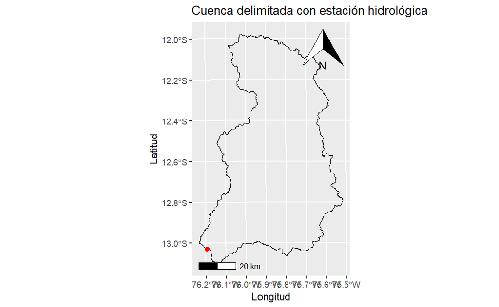

```r
#Se lee el archivo .shp y se define como variable
Cuenca_Canete_SAGA = st_read("4_Shp/Cuenca_Canete_SAGA.shp")
Area <- st_area(Cuenca_Canete_SAGA)
Area_km2 <- Area / 1000000

# Graficando un mapa para ver la cuenca
ggplot() +
  geom_sf(data = Cuenca_Canete_SAGA, fill = NA, color = "black") +
  geom_sf(data = st_as_sf(Est_Hidro_utm), color = "red", size = 2) +
  annotation_scale() +
  xlab("Longitud") + ylab("Latitud") +
  annotation_north_arrow(location = 'tr') +
  ggtitle("Cuenca delimitada con estación hidrológica")

ggsave(filename = "3_Figuras/Cuenca_delimitada.png", width = 7, height = 10)
```

# 3. MODELAMIENTO HIDROLÓGICO GR4J

El procedimiento de modelización hidrológica parte de la delimitación de la cuenca ya que la variable area es fundamental, y seguidamente cargamos los datos de caudales diarios recopilados del ANA (Autoridad Nacional del Agua)

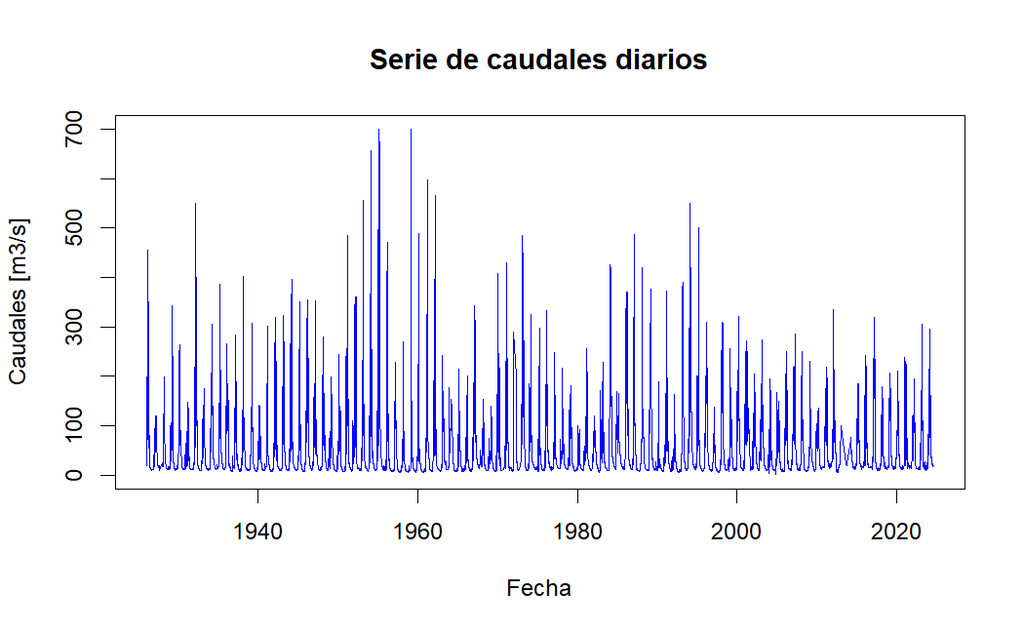

```r
# Ingreso de caudales diarios observados
Caudales_Socsi <- read_excel("2_Caudales/Caudales_Socsi.xlsx",
                             skip = 13)
# View(Caudales_Socsi)

Caudales <- data.frame(Dates = as.Date(Caudales_Socsi$FECHA,
                                       format = "%d/%m/%Y"),
                       Q = Caudales_Socsi$`VALOR (m³/s)`)

# graficando la serie de caudales

plot(Caudales,
     col = "blue",
     type = "l",
     xlab = "Fecha",
     ylab = "Caudales [m3/s]",
     main = "Serie de caudales diarios")
```

Ahora procedemos a extraer la información climática de las bases PISCO de precipitaciones y temperaturas (máximas y mínimas), para ello direccionamos donde se encuentren los archivos Netcdf y en base a la cuenca obtenemos la informacion promedio areal de la cuenca

```r
Cuenca <- readOGR(dsn = "4_Shp/", layer = "Cuenca_canete_SAGA")
Cuenca <- spTransform(Cuenca, CRS("+proj=longlat +datum=WGS84 +no_defs "))
# Ingreso de datos de precipitación y temperatura
PISCO_PR <- raster::brick("D:/DATOS/PISCO_DATA/PISCOpd_v2.1.nc") #Precipitaciones
PISCO_TX <- raster::brick("D:/DATOS/PISCO_DATA/TEMP_MAX/PISCOdtx_v1.1.nc") #Temperatura Maxima
PISCO_TN <- raster::brick("D:/DATOS/PISCO_DATA/TEMP_MIN/PISCOdtn_v1.1.nc") #Temperatura minima

# Extrayendo la informacion
Serie_Pr <- c(rowMeans(t(raster::extract(PISCO_PR, Cuenca, fun = mean, small = TRUE))))
Serie_Tx <- c(rowMeans(t(raster::extract(PISCO_TX, Cuenca, fun = mean, small = TRUE))))
Serie_Tn <- c(rowMeans(t(raster::extract(PISCO_TN, Cuenca, fun = mean, small = TRUE))))

# Vector fecha
Dates <- seq.Date(from = as.Date('1981-01-01'),
                  to = as.Date('2016-12-31'),
                  by = 'day')

# Calculo de la Evapotranspiración por Hargreaves
Pet <- SPEI::hargreaves(Tmin = Serie_Tn, Tmax = Serie_Tx,
                        lat = -12, na.rm = T) / 100
```

[output not shown]

```r
# plot(Pet, type = "l")
```

A partir de los datos obtenidos generamos el data frame para incorporarlo al modelo GR4J, este modelo esta con parámetros aleatorios por lo que requiere un ajuste para una correcta simulación hidrológica

```r
Datos_cuenca <- data.frame(Dates = Dates,
                           Pr = Serie_Pr,
                           PET = Pet)
head(Datos_cuenca)
```

|  | Dates | Pr | PET |
| --- | --- | --- | --- |
| X0 | 1981-01-01 | 0.000000 | 1.1863730 |
| X1 | 1981-01-02 | 4.294272 | 1.1133412 |
| X2 | 1981-01-03 | 4.373433 | 1.1033668 |
| X3 | 1981-01-04 | 7.641142 | 0.9700703 |
| X4 | 1981-01-05 | 2.682074 | 0.8705414 |
| X5 | 1981-01-06 | 3.015421 | 0.7707470 |

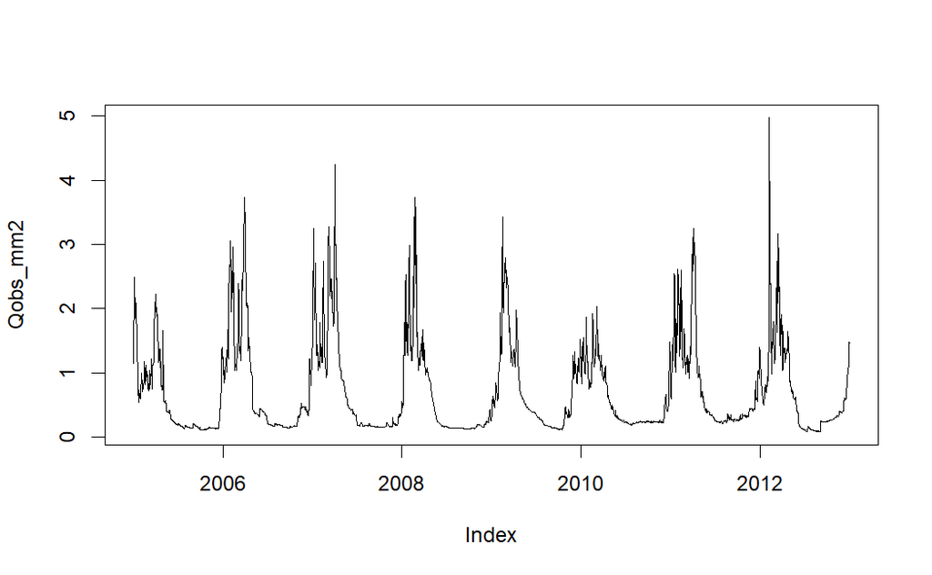

```r
# DEFINIR EL PERIODO DE MODELACIÓN
Date.ini <- as.Date("2005-01-01")
Date.fin <- as.Date("2012-12-31")

Datos_cuenca2 <- Datos_cuenca %>%
  dplyr::filter(Datos_cuenca$Dates <= Date.fin &
  Datos_cuenca$Dates >= Date.ini)
# length(Datos_cuenca2$PET)

# LLevando los caudales de m3 a mm
Caudales2 <- Caudales %>%
  dplyr::filter(Caudales$Dates <= Date.fin & Caudales$Dates >= Date.ini) %>%
  arrange(Dates)
# length(Caudales2$Q)

Qobs_mm <- Caudales2$Q*86400 / ((Area_km2*1000))
Qobs_mm2 <- zoo(x = Qobs_mm, order.by = Caudales2$Dates)
plot(Qobs_mm2)
```

```r
# Datos de la cuenca recopilados o generados
BasinObs <- data.frame(Date = as.POSIXlt(index(Qobs_mm2),
                                         format = '%Y-%m-%d'),
                       Datos_cuenca2,
                       Qobs_mm = as.numeric(Qobs_mm2))
# Ingresos del modelo
help(RunModel_GR4J) # ver ayuda

# Data para el modelo GR4J
InputsModel <- CreateInputsModel(FUN_MOD = RunModel_GR4J,
                                 DatesR = BasinObs$Date,
                                 Precip = BasinObs$Pr,
                                 PotEvap = BasinObs$PET)

# Se recomienda dos años de calentamiento
Ind_Wup <- seq(which(format(BasinObs$Date, format = "%Y-%m-%d") == "2005-01-01"),
               which(format(BasinObs$Date, format = "%Y-%m-%d") == "2006-12-31"))

Ind_Run <- seq(which(format(BasinObs$Date, format = "%Y-%m-%d") == "2007-01-01"),
               which(format(BasinObs$Date, format = "%Y-%m-%d") == "2012-12-31"))
```

Ejecutamos la simulación de los periodos definidos anteriormente y realiamos el grafico para evaluar la salida de cuadales diarios

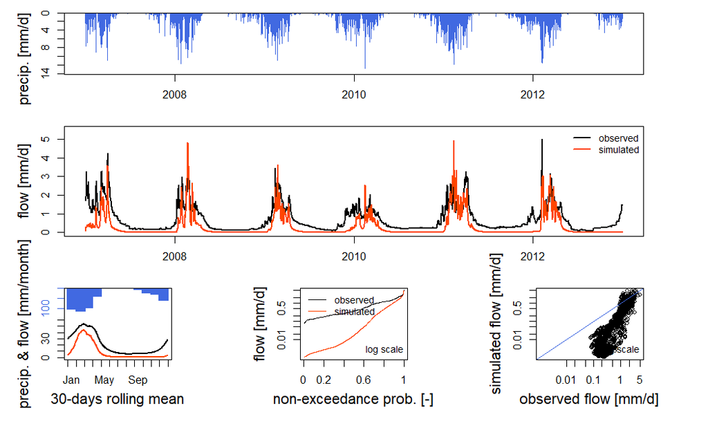

```r
# Simulacion Base sin ajustar parametros
RunOptions <- CreateRunOptions(FUN_MOD = RunModel_GR4J,
                               InputsModel = InputsModel,
                               IndPeriod_WarmUp = Ind_Wup,
                               IndPeriod_Run = Ind_Run)

Param <- c(X1 = 169.017, X2 = -2.376, X3 = 20.697, X4 = 1.417) # Parametros aleatorios

OutputsModel <- RunModel_GR4J(InputsModel = InputsModel,
                              RunOptions = RunOptions,
                              Param = Param)

plot(OutputsModel, Qobs = BasinObs$Qobs_mm[Ind_Run])
```

## 3.1 Calibración hidrológica

```r
# Criterio de calibracion
CalibOptions <- CreateCalibOptions(FUN_MOD = RunModel_GR4J,
                                   FUN_CALIB = Calibration_Michel)

# Ingreso de parametros
InputsCrit <- CreateInputsCrit(FUN_CRIT = ErrorCrit_KGE2,
                               InputsModel = InputsModel,
                               RunOptions = RunOptions,
                               Obs = BasinObs$Qobs_mm[Ind_Run])
```

Se establece el ingreso para encontrar la calibación en el modelo hidrológico

```r
# Encontrando los parametros calibrados
OutputsCalib <- Calibration(InputsModel = InputsModel,
                            RunOptions = RunOptions,
                            InputsCrit = InputsCrit,
                            CalibOptions = CalibOptions,
                            FUN_MOD = RunModel_GR4J,
                            FUN_CALIB = Calibration_Michel)
```

```
Grid-Screening in progress (0% 20% 40% 60% 80% 100%)
     Screening completed (81 runs)
         Param =  432.681,   -0.020,   83.096,    1.417
         Crit. KGE2[Q]      = 0.5731
Steepest-descent local search in progress
     Calibration completed (66 iterations, 631 runs)
         Param =  617.775,    0.600,   17.537,    2.345
         Crit. KGE2[Q]      = 0.8797
```

```r
# Encontrado los parametros calibrados
Param_C <- OutputsCalib$ParamFinalR
Param_C
```

```
[1] 617.7749347   0.5996914  17.5366083   2.3445467
```

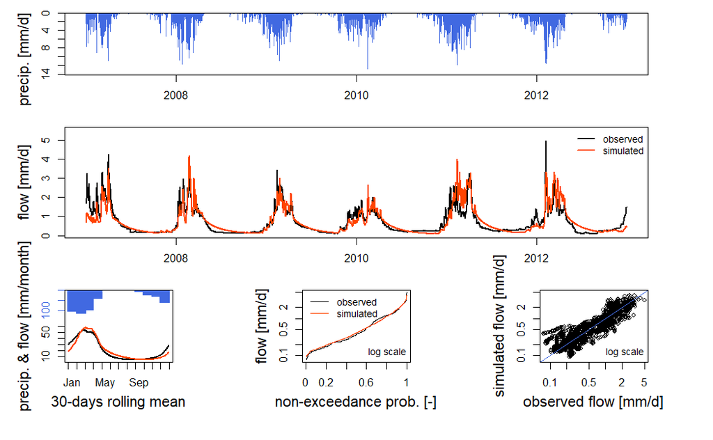

```r
# Ejecutando el modelo con los parametros encontrados
OutputsModel2 <- RunModel(InputsModel = InputsModel,
                         RunOptions = RunOptions,
                         Param = Param_C,
                         FUN = RunModel_GR4J)
plot(OutputsModel2, Qobs = BasinObs$Qobs_mm[Ind_Run])
```

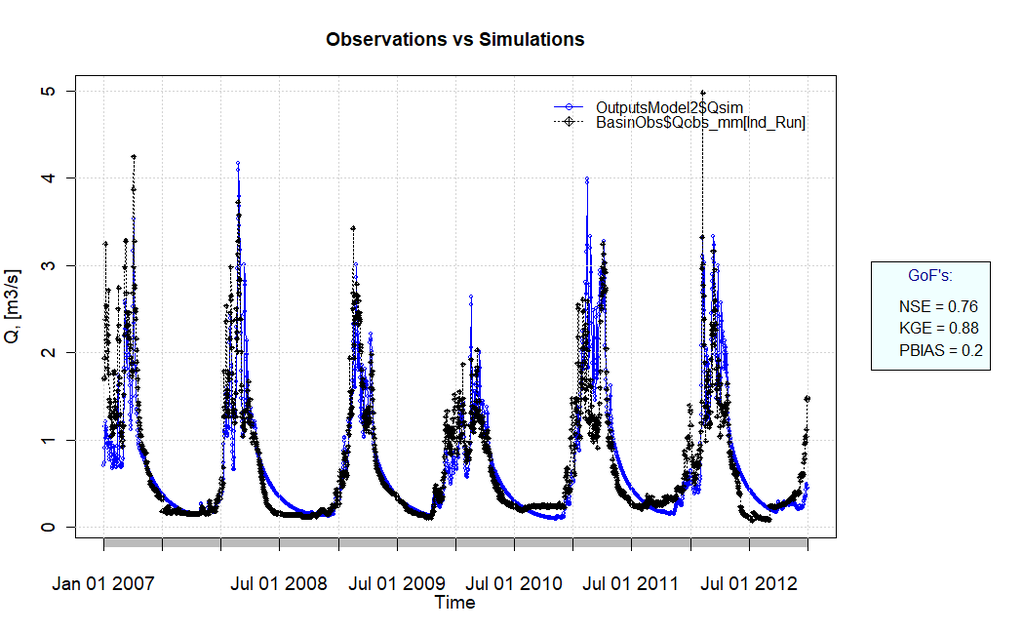

```r
ggof(sim = OutputsModel2$Qsim, obs = BasinObs$Qobs_mm[Ind_Run],
     dates = as.Date(OutputsModel$DatesR),
     na.rm = T, gofs = c("NSE", "KGE", "PBIAS"))
```

## 3.2 Validación hidrológica